# Reproducible Research

Michael Kroog

July 20, 2017

# Reproducible Research Week 2 Project 1

Calculate the total number of steps taken per day

```r
activity <- read.csv("activity.csv", header = TRUE)
totalsum <- with(activity, tapply(steps, date, sum, na.rm = T))
dfsum <- data.frame(date = names(totalsum), steps = totalsum)
```

Histogram of the total number of steps taken per day

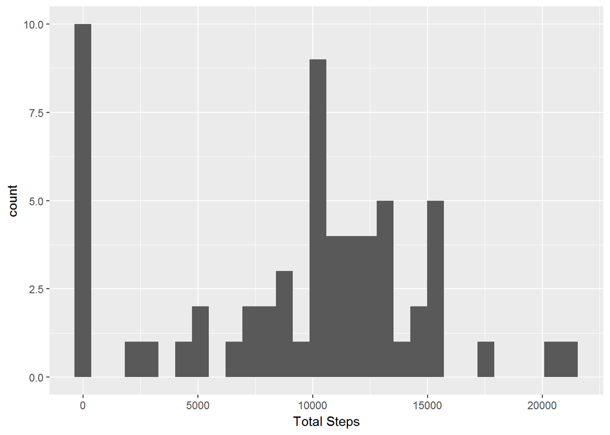

```r
library(ggplot2)
ggplot(data = dfsum, aes(x = steps)) + geom_histogram(bins = 30) + xlab("Total Steps")
```

```r
totalmean <- with(activity, tapply(steps, date, mean, na.rm = T))
dfmean <- data.frame(date = names(totalmean), steps = totalmean)
dfmean <- na.omit(dfmean)

totalmedian <- with(activity, tapply(steps, date, median, na.rm = T))
dfmedian <- data.frame(date = names(totalmedian), steps = totalmedian)
dfmedian <- na.omit(dfmedian)
```

The mean number of steps taken per day

```r
dfmean
```

```
##                  date      steps
## 2012-10-02 2012-10-02  0.4375000
## 2012-10-03 2012-10-03 39.4166667
## 2012-10-04 2012-10-04 42.0694444
## 2012-10-05 2012-10-05 46.1597222
## 2012-10-06 2012-10-06 53.5416667
## 2012-10-07 2012-10-07 38.2465278
## 2012-10-09 2012-10-09 44.4826389
## 2012-10-10 2012-10-10 34.3750000
## 2012-10-11 2012-10-11 35.7777778
## 2012-10-12 2012-10-12 60.3541667
## 2012-10-13 2012-10-13 43.1458333
## 2012-10-14 2012-10-14 52.4236111
## 2012-10-15 2012-10-15 35.2048611
## 2012-10-16 2012-10-16 52.3750000
## 2012-10-17 2012-10-17 46.7083333
## 2012-10-18 2012-10-18 34.9166667
## 2012-10-19 2012-10-19 41.0729167
## 2012-10-20 2012-10-20 36.0937500
## 2012-10-21 2012-10-21 30.6284722
## 2012-10-22 2012-10-22 46.7361111
## 2012-10-23 2012-10-23 30.9652778
## 2012-10-24 2012-10-24 29.0104167
## 2012-10-25 2012-10-25  8.6527778
## 2012-10-26 2012-10-26 23.5347222
## 2012-10-27 2012-10-27 35.1354167
## 2012-10-28 2012-10-28 39.7847222
## 2012-10-29 2012-10-29 17.4236111
## 2012-10-30 2012-10-30 34.0937500
## 2012-10-31 2012-10-31 53.5208333
## 2012-11-02 2012-11-02 36.8055556
## 2012-11-03 2012-11-03 36.7048611
## 2012-11-05 2012-11-05 36.2465278
## 2012-11-06 2012-11-06 28.9375000
## 2012-11-07 2012-11-07 44.7326389
## 2012-11-08 2012-11-08 11.1770833
## 2012-11-11 2012-11-11 43.7777778
## 2012-11-12 2012-11-12 37.3784722
## 2012-11-13 2012-11-13 25.4722222
## 2012-11-15 2012-11-15  0.1423611
## 2012-11-16 2012-11-16 18.8923611
## 2012-11-17 2012-11-17 49.7881944
## 2012-11-18 2012-11-18 52.4652778
## 2012-11-19 2012-11-19 30.6979167
## 2012-11-20 2012-11-20 15.5277778
## 2012-11-21 2012-11-21 44.3993056
## 2012-11-22 2012-11-22 70.9270833
## 2012-11-23 2012-11-23 73.5902778
## 2012-11-24 2012-11-24 50.2708333
## 2012-11-25 2012-11-25 41.0902778
## 2012-11-26 2012-11-26 38.7569444
## 2012-11-27 2012-11-27 47.3819444
## 2012-11-28 2012-11-28 35.3576389
## 2012-11-29 2012-11-29 24.4687500
```

The median number of steps taken per day

```r
dfmedian
```

```
##                  date steps
## 2012-10-02 2012-10-02     0
## 2012-10-03 2012-10-03     0
## 2012-10-04 2012-10-04     0
## 2012-10-05 2012-10-05     0
## 2012-10-06 2012-10-06     0
## 2012-10-07 2012-10-07     0
## 2012-10-09 2012-10-09     0
## 2012-10-10 2012-10-10     0
## 2012-10-11 2012-10-11     0
## 2012-10-12 2012-10-12     0
## 2012-10-13 2012-10-13     0
## 2012-10-14 2012-10-14     0
## 2012-10-15 2012-10-15     0
## 2012-10-16 2012-10-16     0
## 2012-10-17 2012-10-17     0
## 2012-10-18 2012-10-18     0
## 2012-10-19 2012-10-19     0
## 2012-10-20 2012-10-20     0
## 2012-10-21 2012-10-21     0
## 2012-10-22 2012-10-22     0
## 2012-10-23 2012-10-23     0
## 2012-10-24 2012-10-24     0
## 2012-10-25 2012-10-25     0
## 2012-10-26 2012-10-26     0
## 2012-10-27 2012-10-27     0
## 2012-10-28 2012-10-28     0
## 2012-10-29 2012-10-29     0
## 2012-10-30 2012-10-30     0
## 2012-10-31 2012-10-31     0
## 2012-11-02 2012-11-02     0
## 2012-11-03 2012-11-03     0
## 2012-11-05 2012-11-05     0
## 2012-11-06 2012-11-06     0
## 2012-11-07 2012-11-07     0
## 2012-11-08 2012-11-08     0
## 2012-11-11 2012-11-11     0
## 2012-11-12 2012-11-12     0
## 2012-11-13 2012-11-13     0
## 2012-11-15 2012-11-15     0
## 2012-11-16 2012-11-16     0
## 2012-11-17 2012-11-17     0
## 2012-11-18 2012-11-18     0
## 2012-11-19 2012-11-19     0
## 2012-11-20 2012-11-20     0
## 2012-11-21 2012-11-21     0
## 2012-11-22 2012-11-22     0
## 2012-11-23 2012-11-23     0
## 2012-11-24 2012-11-24     0
## 2012-11-25 2012-11-25     0
## 2012-11-26 2012-11-26     0
## 2012-11-27 2012-11-27     0
## 2012-11-28 2012-11-28     0
## 2012-11-29 2012-11-29     0
```

Time series plot of the interval and average number of steps taken per day

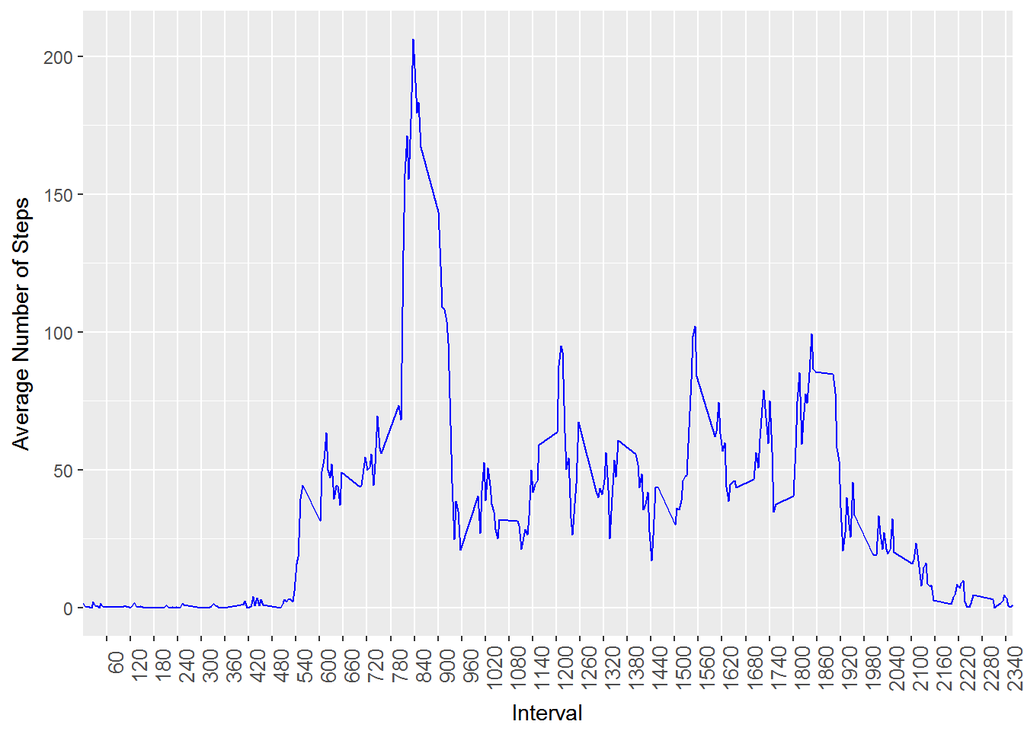

```r
totalinterval <- with(activity, tapply(steps, interval, mean, na.rm = T))
dfinterval <- data.frame(steps = totalinterval, interval = names(totalinterval))

ggplot(dfinterval, aes(x = interval, y = steps)) + geom_line(aes(group = 1), color = "blue") + scale_x_discrete(breaks = seq(60, 2355, 60), limits = 0:2355) + theme(axis.text.x= element_text(size = 10, angle = 90)) + xlab("Interval") + ylab("Average Number of Steps")
```

The plot shows that interval 835 contains on average the maximum number of steps (206)

Total number of missing values

```r
sum(is.na(activity))
```

```
## [1] 2304
```

The total number of missing vales is 2304

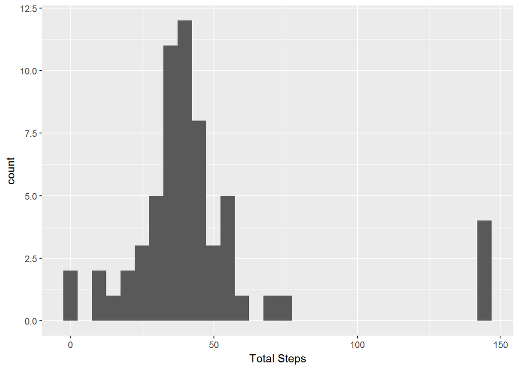

```r
activitynew <- read.csv("activity.csv", header = TRUE)
miss <- which(is.na(activitynew$steps))
dfintervalrep <- sapply(dfinterval, rep.int, times = 4)
activitynew$steps[miss] <- dfintervalrep

activitymean <- with(activitynew, tapply(steps, date, mean, na.rm = T))
dfactivitymean <- data.frame(date = names(activitymean), steps = activitymean)

activitymedian <- with(activitynew, tapply(steps, date, median, na.rm = T))
dfactivitymedian <- data.frame(date = names(activitymedian), steps = activitymedian)

ggplot(data = dfactivitymean, aes(x = steps)) + geom_histogram(bins = 30) + xlab("Total Steps")
```

Imputed mean

```r
dfactivitymean
```

```
##                  date       steps
## 2012-10-01 2012-10-01  37.3825996
## 2012-10-02 2012-10-02   0.4375000
## 2012-10-03 2012-10-03  39.4166667
## 2012-10-04 2012-10-04  42.0694444
## 2012-10-05 2012-10-05  46.1597222
## 2012-10-06 2012-10-06  53.5416667
## 2012-10-07 2012-10-07  38.2465278
## 2012-10-08 2012-10-08  37.3825996
## 2012-10-09 2012-10-09  44.4826389
## 2012-10-10 2012-10-10  34.3750000
## 2012-10-11 2012-10-11  35.7777778
## 2012-10-12 2012-10-12  60.3541667
## 2012-10-13 2012-10-13  43.1458333
## 2012-10-14 2012-10-14  52.4236111
## 2012-10-15 2012-10-15  35.2048611
## 2012-10-16 2012-10-16  52.3750000
## 2012-10-17 2012-10-17  46.7083333
## 2012-10-18 2012-10-18  34.9166667
## 2012-10-19 2012-10-19  41.0729167
## 2012-10-20 2012-10-20  36.0937500
## 2012-10-21 2012-10-21  30.6284722
## 2012-10-22 2012-10-22  46.7361111
## 2012-10-23 2012-10-23  30.9652778
## 2012-10-24 2012-10-24  29.0104167
## 2012-10-25 2012-10-25   8.6527778
## 2012-10-26 2012-10-26  23.5347222
## 2012-10-27 2012-10-27  35.1354167
## 2012-10-28 2012-10-28  39.7847222
## 2012-10-29 2012-10-29  17.4236111
## 2012-10-30 2012-10-30  34.0937500
## 2012-10-31 2012-10-31  53.5208333
## 2012-11-01 2012-11-01  37.3825996
## 2012-11-02 2012-11-02  36.8055556
## 2012-11-03 2012-11-03  36.7048611
## 2012-11-04 2012-11-04  37.3825996
## 2012-11-05 2012-11-05  36.2465278
## 2012-11-06 2012-11-06  28.9375000
## 2012-11-07 2012-11-07  44.7326389
## 2012-11-08 2012-11-08  11.1770833
## 2012-11-09 2012-11-09 144.5000000
## 2012-11-10 2012-11-10 144.5000000
## 2012-11-11 2012-11-11  43.7777778
## 2012-11-12 2012-11-12  37.3784722
## 2012-11-13 2012-11-13  25.4722222
## 2012-11-14 2012-11-14 144.5000000
## 2012-11-15 2012-11-15   0.1423611
## 2012-11-16 2012-11-16  18.8923611
## 2012-11-17 2012-11-17  49.7881944
## 2012-11-18 2012-11-18  52.4652778
## 2012-11-19 2012-11-19  30.6979167
## 2012-11-20 2012-11-20  15.5277778
## 2012-11-21 2012-11-21  44.3993056
## 2012-11-22 2012-11-22  70.9270833
## 2012-11-23 2012-11-23  73.5902778
## 2012-11-24 2012-11-24  50.2708333
## 2012-11-25 2012-11-25  41.0902778
## 2012-11-26 2012-11-26  38.7569444
## 2012-11-27 2012-11-27  47.3819444
## 2012-11-28 2012-11-28  35.3576389
## 2012-11-29 2012-11-29  24.4687500
## 2012-11-30 2012-11-30 144.5000000
```

Imputed median

```r
dfactivitymedian
```

```
##                  date     steps
## 2012-10-01 2012-10-01  34.11321
## 2012-10-02 2012-10-02   0.00000
## 2012-10-03 2012-10-03   0.00000
## 2012-10-04 2012-10-04   0.00000
## 2012-10-05 2012-10-05   0.00000
## 2012-10-06 2012-10-06   0.00000
## 2012-10-07 2012-10-07   0.00000
## 2012-10-08 2012-10-08  34.11321
## 2012-10-09 2012-10-09   0.00000
## 2012-10-10 2012-10-10   0.00000
## 2012-10-11 2012-10-11   0.00000
## 2012-10-12 2012-10-12   0.00000
## 2012-10-13 2012-10-13   0.00000
## 2012-10-14 2012-10-14   0.00000
## 2012-10-15 2012-10-15   0.00000
## 2012-10-16 2012-10-16   0.00000
## 2012-10-17 2012-10-17   0.00000
## 2012-10-18 2012-10-18   0.00000
## 2012-10-19 2012-10-19   0.00000
## 2012-10-20 2012-10-20   0.00000
## 2012-10-21 2012-10-21   0.00000
## 2012-10-22 2012-10-22   0.00000
## 2012-10-23 2012-10-23   0.00000
## 2012-10-24 2012-10-24   0.00000
## 2012-10-25 2012-10-25   0.00000
## 2012-10-26 2012-10-26   0.00000
## 2012-10-27 2012-10-27   0.00000
## 2012-10-28 2012-10-28   0.00000
## 2012-10-29 2012-10-29   0.00000
## 2012-10-30 2012-10-30   0.00000
## 2012-10-31 2012-10-31   0.00000
## 2012-11-01 2012-11-01  34.11321
## 2012-11-02 2012-11-02   0.00000
## 2012-11-03 2012-11-03   0.00000
## 2012-11-04 2012-11-04  34.11321
## 2012-11-05 2012-11-05   0.00000
## 2012-11-06 2012-11-06   0.00000
## 2012-11-07 2012-11-07   0.00000
## 2012-11-08 2012-11-08   0.00000
## 2012-11-09 2012-11-09 144.50000
## 2012-11-10 2012-11-10 144.50000
## 2012-11-11 2012-11-11   0.00000
## 2012-11-12 2012-11-12   0.00000
## 2012-11-13 2012-11-13   0.00000
## 2012-11-14 2012-11-14 144.50000
## 2012-11-15 2012-11-15   0.00000
## 2012-11-16 2012-11-16   0.00000
## 2012-11-17 2012-11-17   0.00000
## 2012-11-18 2012-11-18   0.00000
## 2012-11-19 2012-11-19   0.00000
## 2012-11-20 2012-11-20   0.00000
## 2012-11-21 2012-11-21   0.00000
## 2012-11-22 2012-11-22   0.00000
## 2012-11-23 2012-11-23   0.00000
## 2012-11-24 2012-11-24   0.00000
## 2012-11-25 2012-11-25   0.00000
## 2012-11-26 2012-11-26   0.00000
## 2012-11-27 2012-11-27   0.00000
## 2012-11-28 2012-11-28   0.00000
## 2012-11-29 2012-11-29   0.00000
## 2012-11-30 2012-11-30 144.50000
```

```r
identical(dfmean, dfactivitymean)
```

```
## [1] FALSE
```

```r
identical(dfmedian ,dfactivitymedian)
```

```
## [1] FALSE
```

The values of the means and medians of original data are different from the values of the adjusted data.

```r
values <- rep("missing", times = 53)
values <- append(values, rep("imputed", times =61))
newdfmean <- rbind(dfmean, dfactivitymean)
newdfmean$values <- factor(cbind(values))
```

The impact of adding values in place of NAs results are displayed in the following plot

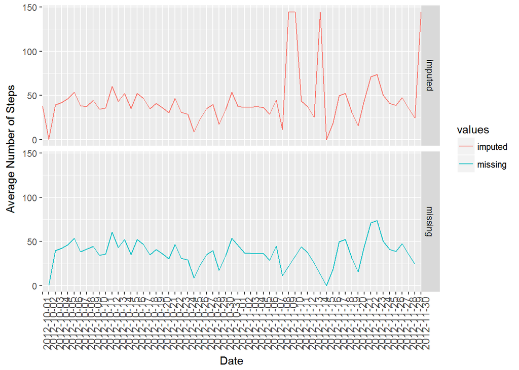

```r
ggplot(newdfmean, aes(x = date, y = steps, color = values)) + geom_line(aes(group = 1)) + facet_grid(values ~ .) + xlab("Date") + ylab("Average Number of Steps") + theme(axis.text.x = element_text(size = 10, angle = 90)) + scale_x_discrete(expand=c(0.001, 0))
```

Creates a new factor variable indicating whether a day is a weekday or weekend

```r
activityweek <- activitynew
activityweek$weekday <- weekdays(as.Date(activityweek$date))
activityweek$weekday <- gsub("S.*y","Weekend", activityweek$weekday)
activityweek$weekday <- factor(gsub("[MTWF].*y","Weekday", activityweek$weekday))
```

Time series panel plot of 5-minute intervals and average steps taken

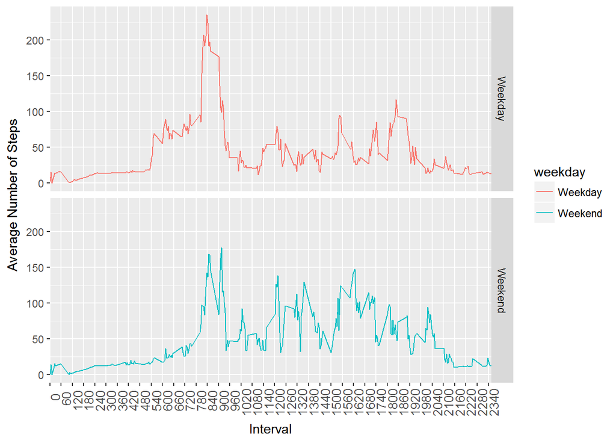

```r
activityweekend <- activityweek[which(activityweek$weekday %in% "Weekend"),]
activityweekday <- activityweek[which(activityweek$weekday %in% "Weekday"),]

activityweekendmean <- with(activityweekend, tapply(steps, interval, mean))
activityweekendmean <- data.frame(steps = activityweekendmean, interval = names(activityweekendmean))
activityweekdaymean <- with(activityweekday, tapply(steps, interval, mean))
activityweekdaymean <- data.frame(steps = activityweekdaymean, interval = names(activityweekdaymean))

activityweekendmean$weekday <- cbind(rep("Weekend", each = 288))
activityweekdaymean$weekday <- cbind(rep("Weekday", each = 288))

dfweekmean <- rbind(activityweekendmean, activityweekdaymean)
dfweekmean$weekday <- factor(dfweekmean$weekday)

ggplot(dfweekmean, aes(x = interval, y = steps, color = weekday)) + geom_line(aes(group = 1)) + scale_x_discrete(breaks = seq(0, 2355, 60), limits = 0:2355) + theme(axis.text.x= element_text(size = 10, angle = 90)) + facet_grid(weekday ~ .) + xlab("Interval") + ylab("Average Number of Steps")
```